# Autoconvolution vs. auto-correlation.

# Are they same?

```python
import numpy as np
import pandas as pd
from netCDF4 import Dataset
import matplotlib.pyplot as plt
from matplotlib import gridspec
from scipy import signal
from scipy.signal import butter, lfilter, freqz
from numpy import arange, sin, pi, angle
```

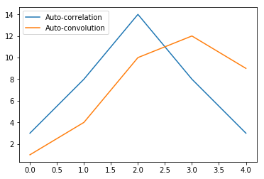

```python
x=np.array([1.0,2.0,3.0])
y=np.correlate(x,x,"full")
plt.plot(y,label='Auto-correlation')
z=np.convolve(x,x)
plt.plot(z,label='Auto-convolution')
plt.legend(loc='upper left')
plt.show()
```

For f(t)= {1, 2, 3} Auto-correlation: (f٭f)(n)= ∑f(t)f(n+t) (n represents the lag) t -3 -2 -1 0 1 2 3 4 f(t) 1 2 3 f(1+t) 1 2 3 f(2+t) 1 2 3 f(t-1) 1 2 3 F(t-2) 1 2 3 (f٭f)(-2)=∑f(t)f(t-2)=f(2)f(0)=3 (f٭f)(-1)=∑f(t)f(t-1)=f(2)f(1)+f(1)f(0)=2+6=8 (f٭f)(0) =∑f(t)f(t)=f(0)f(0)+f(1)f(1)+f(2)f(2)=1+4+9=14 (f٭f)(1) =∑f(t)f(1+t)=f(0)f(1)+f(1)f(2)=2+6=8 (f٭f)(2) =∑f(t)f(2+t)=f(0)f(2)=3 (f٭f)(t)= {3,8,14,8,3} Auto-convolution: (f*f)(t)=∑f(t)f(n-t) t -3 -2 -1 0 1 2 3 f(t) 1 2 3 f(-t) 3 2 1 f(1-t) 3 2 1 f(2-t) 3 2 1 f(3-t) 3 2 1 f(4-t) 3 2 1 (f*f)(0)=∑f(t)f(-t)=f(0)f(0)=1 (f*f)(1)=∑f(t)f(1-t)=f(0)f(1)+f(1)f(0)+f(2)f(-1)=2+2=4 (f*f)(2)=∑f(t)f(2-t)=f(0)f(2)+f(1)f(1)+f(2)f(0)=3+4+3=10 (f*f)(3)=∑f(t)f(3-t)=f(1)f(2)+f(2)f(1)=6+6=12 (f*f)(4)=∑f(t)f(4-t)=f(2)f(2)=9 (f*f)(t)= {1,4,10,12,9} Therefore, autocorrelation and auto-convolution are not the same.